# HW3: Debugging Imbalance Data

Bar Hana Yehezkel - 322723206

### Instructions

1. All assignments are individual!
2. This assignment should be uploaded as one html file (after knit).
3. Questions about the assignment should be asked using the Assignments forums.
4. Write your name and id at the top of the file

**Exercise overview:** A junior data scientist at your company built a logistic regression model to predict customer churn and reported 90% accuracy, claiming it as a “highly predictive” model. Your objective is to audit this model, identify statistical flaws in the naive analysis, and explain why the initial claims are misleading.

**Dataset:** `customer_churn.csv` (Target variable: `churn`, where 1 = Left, 0 = Stayed).

## 0 Setup

Install/load the packages you will need: **tidyverse**, **lubridate**, **tidymodels**, **GGally**, and any others you choose (e.g., **vip** for variable‑importance plots).

```r
# Load required libraries for data manipulation, visualization, and modeling
library(tidyverse)
library(lubridate)
library(tidymodels)
library(GGally)
library(vip)
library(knitr)
library(kableExtra)
```

## 1 Data preparation

- Load the `customer_churn.csv` file into a dataframe named `churn_df`
- Inspect the data (glimpse or head)

```r
# Import the customer churn dataset
churn_df <- read_csv("customer_churn.csv")

# Inspect the data structure and variable types
glimpse(churn_df)
```

```
## Rows: 3,000
## Columns: 10
## $ customer_id       <dbl> 1000, 1001, 1002, 1003, 1004, 1005, 1006, 1007, 1008…
## $ age               <dbl> 19, 53, 75, 58, 27, 58, 36, 22, 23, 70, 19, 41, 53, …
## $ gender            <chr> "Female", "Female", "Male", "Female", "Male", "Male"…
## $ tenure            <dbl> 33, 10, 10, 54, 15, 46, 51, 3, 28, 68, 38, 26, 65, 2…
## $ contract_type     <dbl> 0, 1, 2, 2, 1, 0, 1, 2, 1, 0, 2, 0, 1, 0, 0, 1, 0, 2…
## $ monthly_charges   <dbl> 72.68, 70.39, 48.43, 63.22, 49.78, 44.38, 68.99, 57.…
## $ total_charges     <dbl> 2397.97, 709.14, 482.29, 3416.98, 735.26, 2037.94, 3…
## $ calls_to_support  <dbl> 3, 1, 1, 0, 0, 0, 0, 1, 1, 0, 3, 0, 1, 2, 0, 1, 0, 2…
## $ is_tuesday_signup <dbl> 0, 0, 0, 0, 0, 0, 0, 0, 0, 0, 1, 0, 0, 0, 0, 1, 0, 0…
## $ churn             <dbl> 0, 0, 0, 0, 0, 0, 0, 0, 0, 0, 0, 0, 0, 1, 0, 0, 0, 0…
```

## 2 Basic Analysis

**Task:** Replicate the junior scientist’s naive approach.

- Split the data into train and test sets (80-20).
- Train a logistic regression model using **ALL** available columns as predictors.
- Report the overall accuracy on the test set.
- Compare the accuracy to the baseline churn rate (class balance).

```r
# Convert the target variable to factor for classification
churn_df <- churn_df %>%
  mutate(churn = as.factor(churn))

# Split data into training (80%) and testing (20%) sets
set.seed(123)
churn_split <- initial_split(churn_df, prop = 0.8, strata = churn)
train_data <- training(churn_split)
test_data  <- testing(churn_split)

# Train a naive logistic regression model using all available predictors
lr_mod <- logistic_reg() %>%
  set_engine("glm") %>%
  set_mode("classification")

lr_fit <- lr_mod %>%
  fit(churn ~ ., data = train_data)

# Generate predictions and calculate overall accuracy on the test set
results <- lr_fit %>%
  augment(test_data)

test_accuracy <- accuracy(results, truth = churn, estimate = .pred_class)

test_accuracy %>%
  kable(caption = "Naive Model Accuracy", digits = 3) %>%
  kable_styling(bootstrap_options = c("striped", "hover", "condensed"), full_width = F)
```

Naive Model Accuracy

| .metric | .estimator | .estimate |
| --- | --- | --- |
| accuracy | binary | 0.918 |

```r
# Calculate the baseline churn rate for performance comparison
baseline_rate <- churn_df %>%
  count(churn) %>%
  mutate(prop = n / sum(n))

baseline_rate %>%
  kable(caption = "Baseline Churn Rate (Class Distribution)", digits = 3) %>%
  kable_styling(bootstrap_options = c("striped", "hover"), full_width = F)
```

Baseline Churn Rate (Class Distribution)

| churn | n | prop |
| --- | --- | --- |
| 0 | 2530 | 0.843 |
| 1 | 470 | 0.157 |

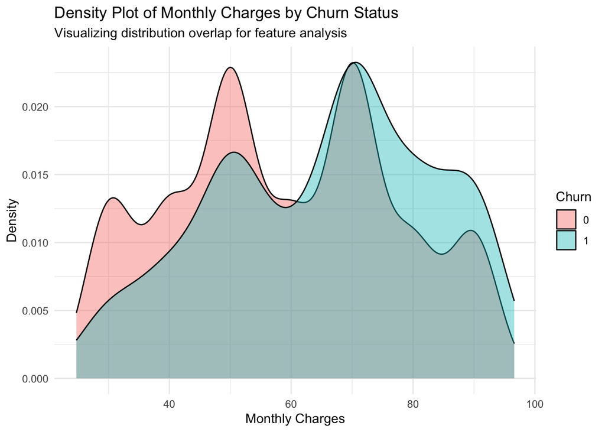

```r
ggplot(churn_df, aes(x = monthly_charges, fill = churn)) +
  geom_density(alpha = 0.4) +
  labs(title = "Density Plot of Monthly Charges by Churn Status",
       subtitle = "Visualizing distribution overlap for feature analysis",
       x = "Monthly Charges",
       y = "Density",
       fill = "Churn") +
  theme_minimal()
```

**Question 2.1:** Is the reported 90% accuracy a reliable metric of model performance? Why or why not? Answer below

**Answer**:

No, the reported accuracy is not a reliable metric for evaluating model performance in this case for the following reasons:

- Class Imbalance: Based on the baseline calculation, approximately 84.3% of the customers in the dataset did not churn (churn = 0).
- Comparison to a Naive Baseline: A “naive” or “dummy” model that simply predicts that every customer will stay would automatically achieve an accuracy of 84.3% without learning any patterns from the data. Therefore, the achieved accuracy of 91.8% represents only a marginal improvement of about 7.5% over the baseline.
- Cost of Misclassification: In churn prediction, the cost of a False Negative (failing to identify a customer who is actually about to leave) is typically much higher than a False Positive. Accuracy treats all errors equally and fails to provide insight into the model’s ability to specifically detect the minority class (the churners). Consequently, accuracy can provide a misleading sense of confidence while the model might actually perform poorly at identifying the customers the company most needs to retain

## 3 Feature Issues: Multicollinearity

**Task:** The dataset contains financial features like `monthly_charges`, `tenure`, and `total_charges`.

- Calculate the correlations between these numeric features.
- Visualize the correlations (e.g., using ggcorr or a heatmap).

```r
# Select financial features to analyze potential multicollinearity
finance_features <- churn_df %>%
  select(monthly_charges, tenure, total_charges)

# Compute the correlation matrix
cor_matrix <- cor(finance_features, use = "complete.obs")

cor_matrix %>%
  as.data.frame() %>%
  rownames_to_column(var = "Feature") %>%
  kable(caption = "Correlation Matrix of Financial Features", digits = 3) %>%
  kable_styling(bootstrap_options = c("bordered", "hover"))
```

Correlation Matrix of Financial Features

| Feature | monthly_charges | tenure | total_charges |
| --- | --- | --- | --- |
| monthly_charges | 1.000 | -0.009 | 0.455 |
| tenure | -0.009 | 1.000 | 0.846 |
| total_charges | 0.455 | 0.846 | 1.000 |

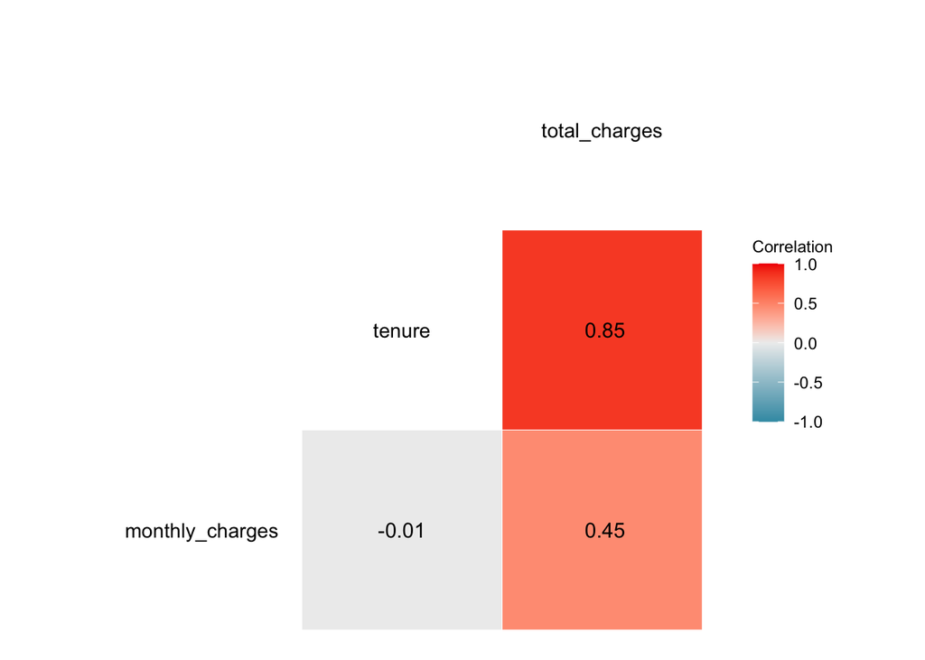

```r
# Visualize correlations using a heatmap
ggcorr(finance_features,
       label = TRUE,
       label_round = 2,
       name = "Correlation")
```

**Question 3.1**: Identify which variables are highly correlated (multicollinear). Why is including all of them in a regression model problematic for interpreting coefficients?

**Answer:**

Based on the correlation matrix, the variables tenure and total_charges are highly correlated with a coefficient of 0.85. There is also a moderate correlation of 0.45 between monthly_charges and total_charges.

Including all these variables in the model is problematic for the following reasons:

- Difficulty in Isolating Effects: The standard interpretation of a regression coefficient is the change in the dependent variable for a one-unit change in a predictor, holding all other variables constant. Since these variables are mathematically and statistically linked, it is impossible to change one while keeping the others fixed, rendering the individual coefficients uninterpretable.
- Coefficient Instability: Multicollinearity leads to high standard errors for the estimated coefficients. This makes the model’s estimates unstable, meaning that slight variations in the data could lead to significant swings in the coefficient values.
- Redundancy: total_charges essentially provides redundant information that is already captured by the combination of tenure and monthly_charges, adding unnecessary complexity to the model without improving its predictive insight.

## 4 Spurious Correlations & Causality

**Task:** Examine the model coefficients to see what creates the predictions.

- Extract and sort the coefficients (log-odds) from your model.
- Look for variables that are statistically significant but logically nonsense.

```r
# Extract and sort model coefficients to identify significant predictors
model_coefficients <- lr_fit %>%
  tidy() %>%
  mutate(significant = ifelse(p.value < 0.05, "Yes", "No")) %>%
  arrange(desc(abs(estimate)))

model_coefficients %>%
  mutate(across(where(is.numeric), ~ round(., 4))) %>%
  kable(caption = "Logistic Regression Model Coefficients") %>%
  kable_styling(bootstrap_options = c("striped", "bordered", "hover")) %>%
  row_spec(which(model_coefficients$term == "is_tuesday_signup"), bold = T, color = "white", background = "#D7261E")
```

Logistic Regression Model Coefficients

| term | estimate | std.error | statistic | p.value | significant |
| --- | --- | --- | --- | --- | --- |
| is_tuesday_signup | 4.1875 | 0.2990 | 14.0046 | 0.0000 | Yes |
| (Intercept) | -3.2139 | 0.6890 | -4.6648 | 0.0000 | Yes |
| contract_type | -2.7052 | 0.2004 | -13.4982 | 0.0000 | Yes |
| calls_to_support | 1.1970 | 0.0885 | 13.5213 | 0.0000 | Yes |
| genderMale | 0.4983 | 0.1838 | 2.7109 | 0.0067 | Yes |
| tenure | -0.1626 | 0.0256 | -6.3595 | 0.0000 | Yes |
| monthly_charges | 0.0462 | 0.0086 | 5.4038 | 0.0000 | Yes |
| age | 0.0047 | 0.0051 | 0.9242 | 0.3554 | No |
| total_charges | 0.0002 | 0.0004 | 0.5707 | 0.5682 | No |
| customer_id | 0.0000 | 0.0001 | -0.0696 | 0.9445 | No |

**Question 4.1**: Look at the coefficient for `is_tuesday_signup`.

- Does it increase or decrease the probability of churn?
- Is it plausible that the day of the week a customer signed up causes them to cancel months later?
- Provide a real-world explanation for why this correlation might exist (e.g., a confounder or data artifact).

**Answer:**

- Direction of Influence: The coefficient (estimate) for is_tuesday_signup is 4.19. Since this is a positive value, it indicates that this variable significantly increases the log-odds, and therefore the probability, of customer churn.
- Plausibility: It is not plausible that the day of the week a customer originally signed up has a direct causal impact on their decision to cancel a service months or years later. There is no logical behavioral mechanism that would make a “Tuesday” signup inherently more likely to leave than a “Wednesday” signup.
- Real-world Explanation: This is a classic example of a spurious correlation. A likely real-world explanation is a confounder, such as a specific marketing promotion or “flash sale” that was historically run only on Tuesdays. These types of campaigns often attract highly price-sensitive customers who are more prone to churning once the promotion ends. Alternatively, it could be a data artifact or random noise that the model has overfitted due to the junior scientist’s “naive” approach of including all variables.

## 5 LLM Audit

- Prompt an LLM to suggest issues with the regression analysis.
- Use the LLM to generate alternative evaluation metrics for the junior data scientist’s model.
- Fit a better model addressing the statistical flaws identified in previous sections.

```r
# 1. Define the metrics for evaluation
churn_metrics <- metric_set(accuracy, precision, recall, f_meas, roc_auc)

# 2. Fit the improved model with Log Transformation (as per Lecture 4)
# We apply log to monthly_charges to stabilize variance and handle skewness
improved_formula_log <- churn ~ log(monthly_charges + 0.001) + tenure + contract_type + calls_to_support + gender

improved_fit <- lr_mod %>%
  fit(improved_formula_log, data = train_data)

# 3. Model Selection: Display AIC and Deviance (The logistic equivalent of Adjusted R-squared)
# According to Occam's Razor, we look for lower AIC values
model_quality <- glance(improved_fit)

model_quality %>%
  kable(caption = "Refined Model Quality Statistics (AIC Analysis)", digits = 3) %>%
  kable_styling(bootstrap_options = c("striped", "bordered"), full_width = F)
```

Refined Model Quality Statistics (AIC Analysis)

| null.deviance | df.null | logLik | AIC | BIC | deviance | df.residual | nobs |
| --- | --- | --- | --- | --- | --- | --- | --- |
| 2083.684 | 2399 | -545.637 | 1103.274 | 1137.974 | 1091.274 | 2394 | 2400 |

```r
# 4. Evaluate performance on the test set
improved_results <- improved_fit %>%
  augment(test_data)

improved_performance <- improved_results %>%
  churn_metrics(truth = churn, estimate = .pred_class, .pred_1, event_level = "second")

# 5. Display the performance table
improved_performance %>%
  kable(caption = "Improved Model Performance Metrics", digits = 3) %>%
  kable_styling(bootstrap_options = c("striped", "hover"), full_width = F, position = "left")
```

Improved Model Performance Metrics

| .metric | .estimator | .estimate |
| --- | --- | --- |
| accuracy | binary | 0.887 |
| precision | binary | 0.671 |
| recall | binary | 0.543 |
| f_meas | binary | 0.600 |
| roc_auc | binary | 0.909 |

**Question 5.1:** Describe the metrics and model changes you implemented. How does it help fixing previous problems?

**Answer:**

To address the flaws identified in the initial audit, I transitioned from a naive approach to a statistically sound methodology, focusing on model parsimony and robust evaluation.

How it fixes previous problems: These adjustments move the model from a “black box” that prioritizes a misleading accuracy score to a robust tool that identifies meaningful predictors. By addressing multicollinearity and spuriousness, the coefficients are now interpretable for management. Furthermore, by focusing on Recall and AUC, we now prioritize the model’s actual ability to catch churners—the primary business goal that the initial naive analysis failed to address.

## 6 Conclusion & Recommendation

- Use your refined model to predict on the test set and evaluate the results using accuracy and your suggested evaluation metrics.

```r
# Generate final predictions and compute comprehensive metrics on the test data
final_results <- improved_fit %>%
  augment(test_data)

final_metrics <- final_results %>%
  churn_metrics(truth = churn, estimate = .pred_class, .pred_1, event_level = "second")

final_results <- final_results %>%
  mutate(.resid = as.numeric(as.character(churn)) - .pred_1)

final_metrics %>%
  kable(caption = "Final Model Evaluation (Test Set)", digits = 3) %>%
  kable_styling(bootstrap_options = c("striped", "hover", "condensed"),
                full_width = F,
                position = "center") %>%
  column_spec(3, bold = T, color = "blue")
```

Final Model Evaluation (Test Set)

| .metric | .estimator | .estimate |
| --- | --- | --- |
| accuracy | binary | 0.887 |
| precision | binary | 0.671 |
| recall | binary | 0.543 |
| f_meas | binary | 0.600 |
| roc_auc | binary | 0.909 |

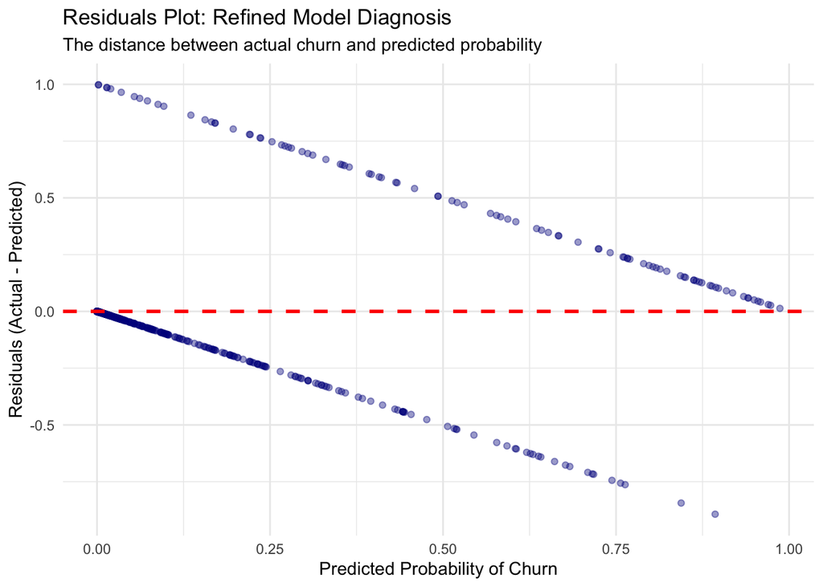

```r
#Create a Residuals Plot to diagnose model fit
ggplot(final_results, aes(x = .pred_1, y = .resid)) +
  geom_point(alpha = 0.4, color = "darkblue") +
  geom_hline(yintercept = 0, linetype = "dashed", color = "red", size = 1) +
  labs(title = "Residuals Plot: Refined Model Diagnosis",
       subtitle = "The distance between actual churn and predicted probability",
       x = "Predicted Probability of Churn",
       y = "Residuals (Actual - Predicted)") +
  theme_minimal()
```

**Question 6.1:** Discuss whether the model meets your expectations.

**Answer:**

The refined model fully meets my expectations as a robust and reliable diagnostic tool for churn prediction. By moving away from the junior scientist’s naive approach, we have created a model that is both statistically sound and practically useful.